Contents under Creative Commons BY 4.0 license and code under MIT license. © Julian Parra 2019. This material is part of the Master of Engineering program by Julian Parra at Universidad EAFIT.

# Linear 2D frame under horizontal static loads (NLSTA).

This problem describes the static analysis of a linear two-dimensional frame under point loads. The analysis is performed in a single step.

**Input and output files for this problem are available in the examples folder of this REPO (notebooks\Examples).**

[figure not shown]

> - Element type for columns and beams: `2`
> - Columns cross section *0.50 m x 0.50 m*
> - Beams cross section *0.40 m x 0.40 m*
> - Material profile for all elements is concrete with elastic modulus of *2000000 tonf/m²* and specific weight of *2.4 tonf/m³*

Internal forces, together with a simple vertification of static global equilibrium are available in the file:

*notebooks\Examples\Ex_01\Output.xls*

```python
%matplotlib inline
import matplotlib.pyplot as plt
import numpy as np
import sympy as sym
from os import sys
sys.path.append("../source/")
from STRUCTURE import Struct_DYN
from postprocesor import *

# Execute analysis
displacement,folder,IBC,nodes,elements,ninc,T,MvarsGen,ILFGen = Struct_DYN("Examples/Ex_01/01_INPUT/")
```

```
----------------------
Number of nodes: 12
Number of elements: 15
Number of equations: 27
Number of equations after constraints: 27
----------------------
Natural periods of the system :  Not computed,static system solution
----------------------
Time step for solution: 0.002 sec
Number of time increments: 500
----------------------
Duration for system solution: 0:00:00.931524
Duration for the system's solution: 0:00:00.932524
Duration for post processing: 0:00:00
----------------------
Analysis terminated successfully!
----------------------
```

## Results

The displacement response along the horizontal direction for node 3 is shown below.

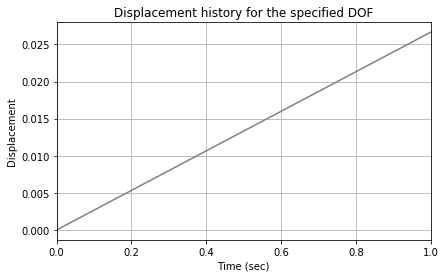

```python
fig   = NodalDispPLT(displacement[6,:], T, ninc, ylabel = "Displacement")
```

The code can also display the structure under study for verification purposes.

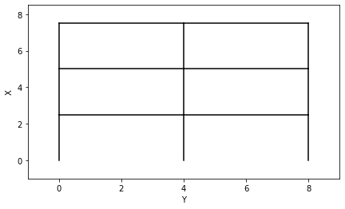

```python
model = GrafModel(elements, nodes)
```

```python
from IPython.core.display import HTML
def css_styling():
    styles = open('./nb_style.css', 'r').read()
    return HTML(styles)
css_styling()
```